# Ford GoBike Dataset Exploration

## Preliminary Wrangling

This data set includes information about individual rides made in a bike-sharing system covering the greater San Francisco Bay area.

```python
# import all packages and set plots to be embedded inline
import numpy as np
import pandas as pd
import matplotlib.pyplot as plt
import seaborn as sb

%matplotlib inline
```

```python
bikes=pd.read_csv('./Ford GoBike.csv')
bikes.head()
```

|  | duration_sec | start_time | end_time | start_station_id | start_station_name | start_station_latitude | start_station_longitude | end_station_id | end_station_name | end_station_latitude | end_station_longitude | bike_id | user_type | member_birth_year | member_gender | bike_share_for_all_trip |
| --- | --- | --- | --- | --- | --- | --- | --- | --- | --- | --- | --- | --- | --- | --- | --- | --- |
| 0 | 52185 | 2019-02-28 17:32:10.1450 | 2019-03-01 08:01:55.9750 | 21.0 | Montgomery St BART Station (Market St at 2nd St) | 37.789625 | -122.400811 | 13.0 | Commercial St at Montgomery St | 37.794231 | -122.402923 | 4902 | Customer | 1984.0 | Male | No |
| 1 | 42521 | 2019-02-28 18:53:21.7890 | 2019-03-01 06:42:03.0560 | 23.0 | The Embarcadero at Steuart St | 37.791464 | -122.391034 | 81.0 | Berry St at 4th St | 37.775880 | -122.393170 | 2535 | Customer | NaN | NaN | No |
| 2 | 61854 | 2019-02-28 12:13:13.2180 | 2019-03-01 05:24:08.1460 | 86.0 | Market St at Dolores St | 37.769305 | -122.426826 | 3.0 | Powell St BART Station (Market St at 4th St) | 37.786375 | -122.404904 | 5905 | Customer | 1972.0 | Male | No |
| 3 | 36490 | 2019-02-28 17:54:26.0100 | 2019-03-01 04:02:36.8420 | 375.0 | Grove St at Masonic Ave | 37.774836 | -122.446546 | 70.0 | Central Ave at Fell St | 37.773311 | -122.444293 | 6638 | Subscriber | 1989.0 | Other | No |
| 4 | 1585 | 2019-02-28 23:54:18.5490 | 2019-03-01 00:20:44.0740 | 7.0 | Frank H Ogawa Plaza | 37.804562 | -122.271738 | 222.0 | 10th Ave at E 15th St | 37.792714 | -122.248780 | 4898 | Subscriber | 1974.0 | Male | Yes |

```python
print(bikes.shape)
print(bikes.dtypes)
```

```
(183412, 16)
duration_sec                 int64
start_time                  object
end_time                    object
start_station_id           float64
start_station_name          object
start_station_latitude     float64
start_station_longitude    float64
end_station_id             float64
end_station_name            object
end_station_latitude       float64
end_station_longitude      float64
bike_id                      int64
user_type                   object
member_birth_year          float64
member_gender               object
bike_share_for_all_trip     object
dtype: object
```

```python
# making the time columns into datetime to make future me work easy with dates
bikes['start_time']=pd.to_datetime(bikes['start_time'])
bikes['end_time']=pd.to_datetime(bikes['end_time'])
```

Feature Engineering a distance column based on the `['start_station_latitude','end_station_latitude','start_station_longitude','end_station_longitude']`  
Visit this [link](https://stackoverflow.com/questions/4913349/haversine-formula-in-python-bearing-and-distance-between-two-gps-points) to learn more on how

```python
# Creating a distance column depending on the longitude and latitude
def haversine(df):
    """
    Calculate the distance in kilometers between two points on  earth

    Parameters:
      Dataframe with (lon1, lat1, lon2, lat2) as columns in that order
    """

    # convert decimal degrees to radians
    lon1, lat1, lon2, lat2 = map(np.radians, [df.iloc[:,0], df.iloc[:,1], df.iloc[:,2], df.iloc[:,3]])

    # haversine formula
    dlon = lon2 - lon1
    dlat = lat2 - lat1
    a = np.sin(dlat/2)**2 + np.cos(lat1) * np.cos(lat2) * np.sin(dlon/2)**2
    c = 2 * np.arcsin(np.sqrt(a))

    # Radius of earth in kilometers. Use 3956 for miles. Determines return value units.
    r = 6371
    return c * r

bikes['distance']=haversine(bikes[['start_station_longitude','start_station_latitude','end_station_longitude','end_station_latitude']])
bikes['distance'].head()
```

```
0    0.544709
1    1.742999
2    2.704545
3    0.260739
4    2.409301
Name: distance, dtype: float64
```

```python
bikes.describe()
```

|  | duration_sec | start_station_id | start_station_latitude | start_station_longitude | end_station_id | end_station_latitude | end_station_longitude | bike_id | member_birth_year | distance |
| --- | --- | --- | --- | --- | --- | --- | --- | --- | --- | --- |
| count | 183412.000000 | 183215.000000 | 183412.000000 | 183412.000000 | 183215.000000 | 183412.000000 | 183412.000000 | 183412.000000 | 175147.000000 | 183412.000000 |
| mean | 726.078435 | 138.590427 | 37.771223 | -122.352664 | 136.249123 | 37.771427 | -122.352250 | 4472.906375 | 1984.806437 | 1.690659 |
| std | 1794.389780 | 111.778864 | 0.099581 | 0.117097 | 111.515131 | 0.099490 | 0.116673 | 1664.383394 | 10.116689 | 1.097589 |
| min | 61.000000 | 3.000000 | 37.317298 | -122.453704 | 3.000000 | 37.317298 | -122.453704 | 11.000000 | 1878.000000 | 0.000000 |
| 25% | 325.000000 | 47.000000 | 37.770083 | -122.412408 | 44.000000 | 37.770407 | -122.411726 | 3777.000000 | 1980.000000 | 0.910955 |
| 50% | 514.000000 | 104.000000 | 37.780760 | -122.398285 | 100.000000 | 37.781010 | -122.398279 | 4958.000000 | 1987.000000 | 1.430738 |
| 75% | 796.000000 | 239.000000 | 37.797280 | -122.286533 | 235.000000 | 37.797320 | -122.288045 | 5502.000000 | 1992.000000 | 2.225687 |
| max | 85444.000000 | 398.000000 | 37.880222 | -121.874119 | 398.000000 | 37.880222 | -121.874119 | 6645.000000 | 2001.000000 | 69.469241 |

### What is the structure of your dataset?

There are 183,412 bike trips in the dataset with 16 features and 1 made by us(distance)

| Data columns | Purpose | Valid values |
| --- | --- | --- |
| duration_sec | Time taken in the trip as seconds | `Int64` |
| start_time end_time | Time stamp when the user Started & Ended the trip | `Datetime` |
| start_Station_id end_Station_id | Unique value of the Starting & Ending station | - |
| start_Station_name end_Station_name | The name of the station name corresponding to the id | - |
| start_station_latitude end_station_latitude | The latitude of the Starting & Ending Station | `Float64 [-90,90]` |
| start_station_longitude end_station_longitude | The longitude of the Starting & Ending Station | `Float64 [-180,180]` |
| distance | The straight line distance between the two stations in kilometers It's obviously not an accurate representative of the distance covered but we might need it | `Float64` km |
| bike_id | Unique Value for the bike id | - |
| user_type | The state of the user | `['Subscriber', 'Customer']` |
| member_birth_year member_gender | The birth year and gender of our user | - `['Male', 'Female','Other']` |
| bike_share_for_all_trip | Wither the bike was shared or not | `['Yes', 'No']` |

### What is/are the main feature(s) of interest in your dataset?

I'm most interested in figuring out what features are best for predicting the duration of the trips in the dataset.

### What features in the dataset do you think will help support your investigation into your feature(s) of interest?

I expect that user_type and distance will have the strongest effect on each trips's duration: if he is a customer , the less the duration and the less distance less the duration. I also think that the other features of trips: member_gender, member_birth_year,distance, and bike share, will have effects on the duration, though to a much smaller degree than the main effect of user_type.

## Univariate Exploration

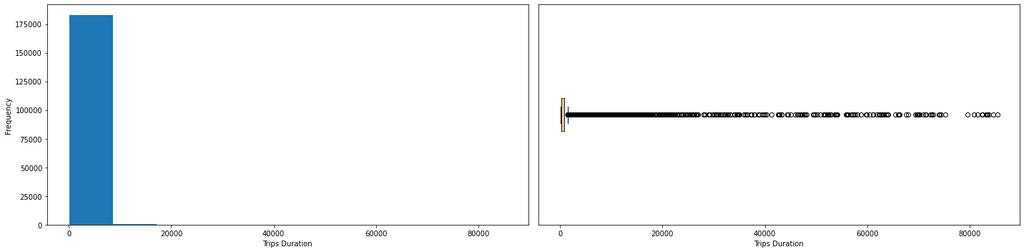

```python
fig,ax=plt.subplots(ncols=2,figsize=(20,5))
ax[0].hist(data=bikes,x='duration_sec')
ax[0].set_xlabel('Trips Duration')
ax[0].set_ylabel('Frequency')

ax[1].boxplot(data=bikes,x='duration_sec',vert=False)
ax[1].set_xlabel('Trips Duration')
ax[1].set_yticks([])
fig.tight_layout()
```

We noticed From the histogram and the BoxPlot that the `duration_sec` column has a lot of outliers so let us filter them  
using the knowledge of that the data which are not outliers lies in the range **(Q1 - 1.5 *IQR, Q3 + 1.5* IQR)**

- Q1: First Quartile represents the 25<sup>th</sup> mark of the data.
- Q3: Third Quartile represents the 75<sup>th</sup> mark of the data.
- IQR : Inter Quartile Range which is (Q3 - Q1)

```python
def remove_outliers(df: pd.DataFrame, col: str) -> pd.DataFrame:
    """
    Getting the DataFrame and the column name then filter the data from outliers based on this column
    """
    #Getting the Q1 and Q3 using the quantile method providing the percentage we want
    Q1 = df[col].quantile(.25)
    Q3 = df[col].quantile(.75)
    IQR = Q3 - Q1
    #Quering the dataframe based on the conditions we said then returning the dataframe
    return df.query(f"{col}>{Q1-1.5*IQR} and {col}<{Q3+1.5*IQR}")

bikes2=remove_outliers(bikes,'duration_sec')

# Printing the shape to see if we succeeded in removing the outliers and we did :)
bikes2.shape
```

```
(173281, 17)
```

We will plot the Histogram and the Box plot of the durations column to see the distribution showing how it varies

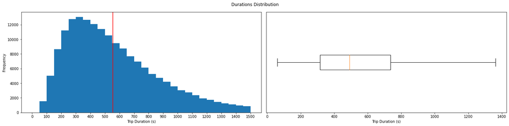

```python
# making subplots to draw our two graphs, increaseing the figure size and providing a Title
fig, ax=plt.subplots(ncols=2,figsize=(20,5))
fig.suptitle('Durations Distribution')

# Drawing a histogram with bins specified to have 50 bin width to show more accurately the distribution then drawing a line indicating the mean
bins=np.arange(0,1500+50,50)
ax[0].hist(data=bikes2,x='duration_sec',bins=bins)
ax[0].set_xlabel('Trip Duration (s)')
ax[0].set_ylabel('Frequency')
# Showing only x ticks of hundreds
ax[0].set_xticks(np.arange(0,1500+100,100))
ax[0].axvline(bikes2['duration_sec'].mean(),color='r')

# Drawing a boxplot to show the quartiles of our data
ax[1].boxplot(data=bikes2,x='duration_sec',vert=False,showfliers=False)
ax[1].set_xlabel('Trip Duration (s)')
ax[1].set_yticks([])

# To auto adjust the margins between thw two plots
fig.tight_layout()
```

As we can see that the durations are Positively(right) Skewed cause mean > median > mode.  
meaning that most trips take approximately 300 seconds (roughly 5 minutes).  
The average trip duration is 550 seconds (roughly 9 minutes).

Now let's find out the distribution of birth_year of our users.

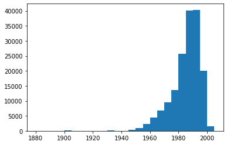

```python
# Setting the bins to be 5 years wide
birth_bins=np.arange(1880,2010,5)
plt.hist(data=bikes2,x='member_birth_year',bins=birth_bins);
```

As we can see that there are some user's birth year below 1940 which doesn't make sense.  
Our dataset is from 2019 so the user must be nearly 80 years old which no one at this age cycles anymore.  
So We are going to filter who those birth_year below 1940.

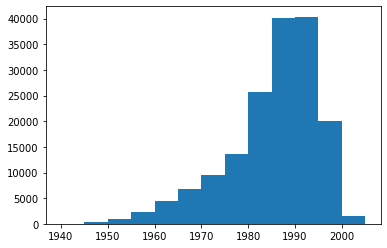

```python
#Quering the birth year larger than the 1940s
bikes2=bikes2.query('member_birth_year >= 1940')

# Setting the bins to be 5 years wide
birth_bins=np.arange(1940,2010,5)
plt.hist(data=bikes2,x='member_birth_year',bins=birth_bins);
```

As we can see we have a Negatively (left) skewed with most people born in the early 1990s  
It matches to our expectation cause most of the cyclists are young,Energized people and our data says they are in the young 24-29 year old range .

Now we see The counts of categorical data we have {user_type, member_gender, bike_share_for_all_trip}

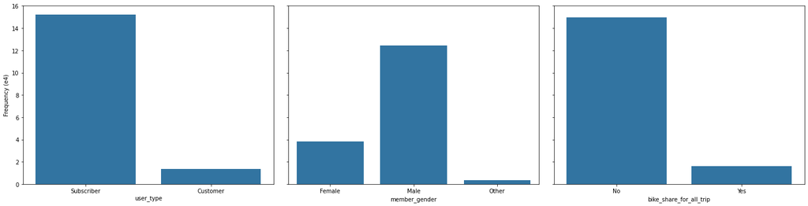

```python
#Making multiple subplots and sharing the y axis to make it easy to compare them directly
fig, ax=plt.subplots(ncols=3, figsize=(20,5), sharey='row')
basic_color=sb.color_palette()[0]
fig.tight_layout()

#Displaying a count plot of each unique value we have in our categorical data
sb.countplot(data=bikes2,x='user_type',ax=ax[0],color=basic_color)
sb.countplot(data=bikes2,x='member_gender',ax=ax[1],color=basic_color)
sb.countplot(data=bikes2,x='bike_share_for_all_trip',ax=ax[2],color=basic_color)

# Changing the ticks to be of two digits instead of 6 to make it easy on the eyes and displaying the label with a factor of e4
ticks=np.arange(0,180000,20000)
plt.yticks(ticks,ticks//10000)
ax[0].set_ylabel('Frequency (e4)')

ax[1].set_ylabel('')
ax[2].set_ylabel('')
```

### Discuss the distribution(s) of your variable(s) of interest. Were there any unusual points? Did you need to perform any transformations?

The duration variable took on a large range of values, so I looked at the data after removing outliers.the data looked unimodal, with one peak between 300s and 350s .

### Of the features you investigated, were there any unusual distributions? Did you perform any operations on the data to tidy, adjust, or change the form of the data? If so, why did you do this?

When investigating the birth_year variable. a number of outlier points were identified as faulted cause they had people older than the logical amount so all of these were removed from the dataset to move forwards.

## Bivariate Exploration

To start off with, I want to look at the pairwise correlations present between features in the data.

```python
quantitative_vs = ['duration_sec', 'member_birth_year', 'distance']
qualitative_vs = ['user_type', 'member_gender', 'bike_share_for_all_trip']
```

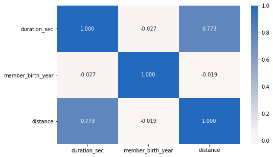

```python
# correlation plot
plt.figure(figsize = [8, 5])
sb.heatmap(bikes2[quantitative_vs].corr(), annot = True, fmt = '.3f',
           cmap = 'vlag_r', center = 0)
```

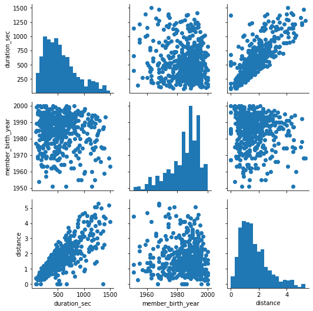

```python
# plot matrix: sample 500 trips so that plots are clearer and they render faster
g = sb.PairGrid(data = bikes2.sample(500), vars = quantitative_vs)
g = g.map_diag(plt.hist, bins = 20);
g.map_offdiag(plt.scatter)
```

As expected, the distance is highly correlated with the duration.  
Surprisingly, the correlation coefficient between birth year and distance and duration is very low, despite the fact that the younger travels faster so take less time.

Let's move on to looking at how duration correlate with the categorical variables.

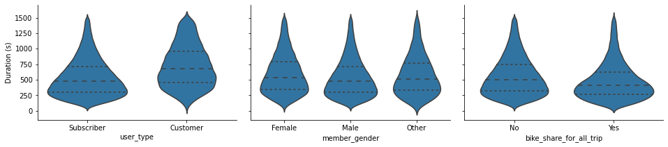

```python
# making a pairplot to plot a violin plot to view the relation we have
# Violin plot instead of box plot to view the distribution a lot better
g = sb.PairGrid(data = bikes2, y_vars = 'duration_sec', x_vars = qualitative_vs,
                height = 3, aspect = 1.5)
g.map(sb.violinplot,inner='quartile',color=basic_color);

# Changing the y label to accurately name the the y axis
g.axes[0][0].set_ylabel('Duration (s)');
```

We see that most subscribers take less time in traveling .  
All genders approximately take the same amount of time gender is neutral in cycling.  
The people who turn off the bike share take more time.

Now now let's see how our categorical variables affects the distance

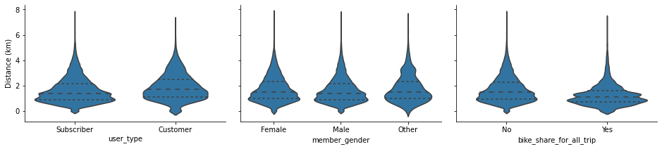

```python
# making a pairplot to plot a violin plot to view the relation we have
# Violin plot instead of box plot to view the distribution a lot better
g = sb.PairGrid(data = bikes2, y_vars = 'distance', x_vars = qualitative_vs,
                height = 3, aspect = 1.5)
g.map(sb.violinplot,inner='quartile',color=basic_color);

# Changing the y label to accurately name the the y axis
g.axes[0][0].set_ylabel('Distance (km)');
```

As we can see The Subscribers Travel less than the Customers.  
All genders approximately travel the same distance.  
People Who turn off their bike share travel slightly more distance than those who don't

Now let's see how time affects the duration

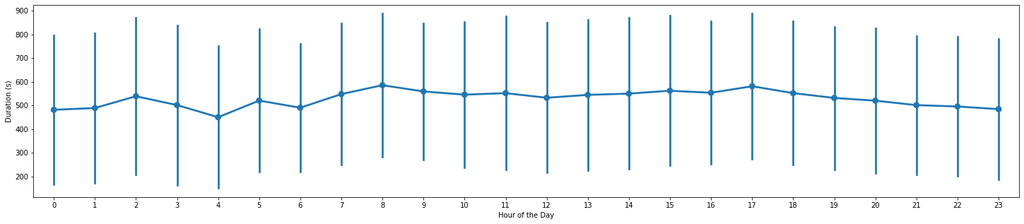

```python
# First we extract the hours of each time
hours=bikes2['start_time'].dt.hour
# Making a subplot although i don't use multiple plots but just to make the figure bigger
fig, ax = plt.subplots(figsize=(25,5))
# Plotting a point plot with the duration on the y-axis and the lines represent the std of the data
sb.pointplot(data=bikes2,y='duration_sec',x=hours,ci='sd',ax=ax)

ax.set_xlabel('Hour of the Day')
ax.set_ylabel('Duration (s)');
```

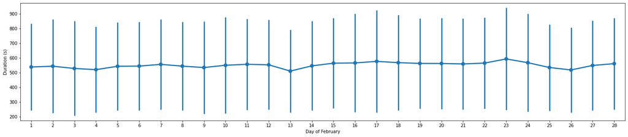

```python
# First we extract the days of each time
feb_days=bikes2['start_time'].dt.day
# Making a subplot although i don't use multiple plots but just to make the figure bigger
fig, ax = plt.subplots(figsize=(25,5))
# Plotting a point plot with the duration on the y-axis and the lines represent the std of the data
sb.pointplot(data=bikes2,y='duration_sec',x=feb_days,ci='sd',ax=ax)

ax.set_xlabel('Day of February')
ax.set_ylabel('Duration (s)');
```

The hours ranges from 0 (midnight) => 23 (11pm) and days from 1<sup>st</sup> => 28<sup>th</sup> of the month of february 2019.  
First for the time of day as we can see the duration in the early hours are lower than at noon and early night cause traffic and other possible factors.  
The day of the month has nearly no affect on the duration of the trip

### Did you observe any interesting relationships between the other features (not the main feature(s) of interest)?

That Subscribers travel less distance than customers.  
Gender doesn't affect the distance nor wither he turned the bike share

## Multivariate Exploration

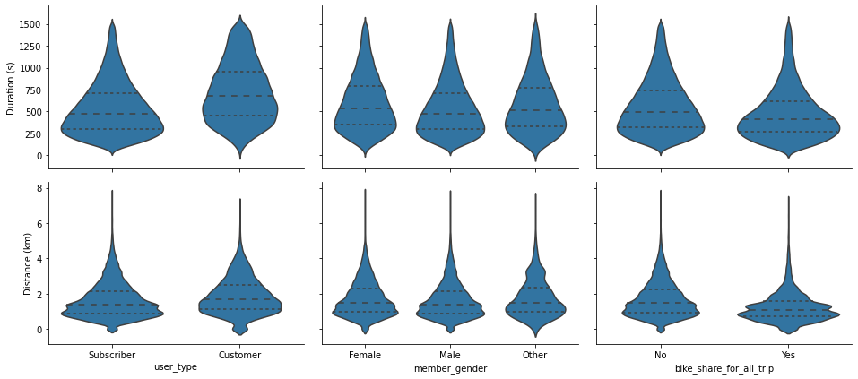

```python
# making a pairplot to plot a violin plot to view the relation we have
# Violin plot instead of box plot to view the distribution a lot better
g = sb.PairGrid(data = bikes2, y_vars = ['duration_sec', 'distance'], x_vars = qualitative_vs,
                height = 3, aspect = 1.5)
g.map(sb.violinplot,inner='quartile',color=basic_color);

# Changing the y labels to accurately name the the y axis
g.axes[1][0].set_ylabel('Distance (km)')
g.axes[0][0].set_ylabel('Duration (s)');
```

We see that most subscribers take less time in traveling but they travel less distance so it balances out.  
Most genders approximately take the same amount of time and travel same distance so gender is neutral in cycling.  
50% people who turn off the bike share take more time but they travels a further distance

Now now let's see how the combination of user_type and gender affects the duration

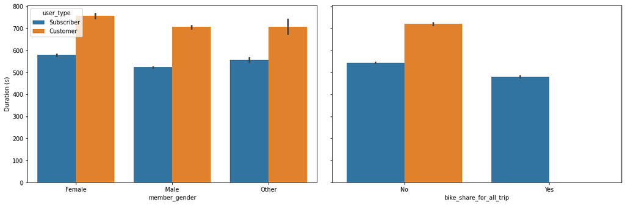

```python
fig,ax=plt.subplots(ncols=2,figsize=(15,5),sharey='row')
sb.barplot(data=bikes2,x='member_gender',y='duration_sec',hue='user_type',ax=ax[0])
sb.barplot(data=bikes2,x='bike_share_for_all_trip',y='duration_sec',hue='user_type',ax=ax[1])

fig.tight_layout()
ax[1].get_legend().remove()
ax[0].set_ylabel('Duration (s)')
ax[1].set_ylabel('');
```

We deduced before that gender doesn't affect the duration but we see here that if we looked at the genders grouped by the type of user we see that average females subscribers and customers take more time than males and that subscribers take less time than customers for each gender and that people who turn off bike share take more time too .

Let's Now see the relation between distance and duration and the affect of gender on them.

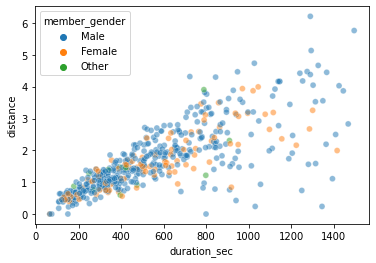

```python
# Sampling tp 500 row only to see the scatter more clearly
sb.scatterplot(data=bikes2.sample(500),x='duration_sec',y='distance',hue='member_gender',alpha=.5);
```

As we can see that there are a lot more males making trips than females going for a larger distance That makes us say that Biking is male dominate transport.

### Talk about some of the relationships you observed in this part of the investigation. Were there features that strengthened each other in terms of looking at your feature(s) of interest?

I extended my investigation of duration in this section by looking at the impact of the three categorical features. The multivariate exploration here showed that there indeed a a relationship between duration ,gender and being a subscriber.

### Were there any interesting or surprising interactions between features?

It's interesting when we looked at the gender vs duration alone and when now we looked at the affect on being a customer does in increasing the female vs male comparison in the affect of duration.